# test

## Библиотеки

```python
import time
import random
from datetime import datetime

from multiprocessing import Pool

import pandas as pd
import numpy as np
from web3 import Web3

import chain_settings
```

**time** - для задержек  
**random** - для рандомизации  
**random** - дата, которая испоьзуется в отчете  
**multiprocessing** - модуль многопроцессной обработки  
**pandas** - инструмент для работы с таблицами, используется для загрузки/создания таблицы с отчетом, для записи данных  
**numpy** - используется для создания диапазона из любых видов чисел - целых или десятичных  
**web3** - подключение к rpc, создание, подпись и отправка транзакций  
**chain_settings** - модуль с настройками чейнов, в которых будут совершаться транзы

## Модуль chain_settings

В файле в виде словарей перечислены сети, в которых будут совершаться транзакции: **name** - название сети, использует для вывода в консоль и в отчете  
**url** - используется для подключения  
**port** - используется для подключения  
**min_amount_for_sending** - минимальная сумма для отправки  
**max_amount_for_sending** - максимальная сумма для отправки  
**explorer_url** - адрес эксплорера  
**explorer_txn_path** - вложенный адрес для просмотра данных о транзакции по хешу  
Можно убрать параметры, если они избыточны, или добавить новые.

```python
polygon = {
            'name': 'Polygon',
            'url':'https://endpoints.omniatech.io/v1/matic/mumbai/public',
            'port':80001,
            'min_amount_for_sending':0.0001,
            'max_amount_for_sending':0.001,
            'explorer_url':'https://mumbai.polygonscan.com',
            'explorer_txn_path':'tx',
            }
```

```python
bsc = {
        'name':'Binance Smart Chain',
        'url':'https://bsc-testnet.public.blastapi.io',
        'port':97,
        'min_amount_for_sending':0.0001,
        'max_amount_for_sending':0.001,
        'explorer_url':'https://testnet.bscscan.com/',
        'explorer_txn_path':'tx',
        }
```

```python
avalanche = {
            'name':'Avalanche',
            'url':'https://endpoints.omniatech.io/v1/avax/fuji/public',
            'port':43113,
            'min_amount_for_sending':0.0001,
            'max_amount_for_sending':0.001,
            'explorer_url':'https://testnet.snowtrace.io',
            'explorer_txn_path':'tx',
            }
```

В _ *all* _ передаются чейны, которые будут использоваться для отправки.

```python
__all__ = ['polygon', 'bsc', 'avalanche']
```

## Config

Название файла, в котором собраны адреса для рандомной отправки

```python
TXT_WITH_RECEPIENT_FOR_RANDOM_SENDING = 'etherscan_adresses.txt'
```

Название файла с приватниками

```python
TXT_WITH_PRIVATE_KEYS = 'private_keys.txt'
```

Название для таблицы с отчетом, которая будет создана, если отсутствует, или будет дополнены, если существует

```python
REPORT_TABLE_NAME = 'report_table.csv'
```

Количество транзакций в цикле

```python
NUMBER_OF_TRANSACTIONS = 10
```

Количество вариаций, которое будет в диапазоне между min_amount_for_sending и max_amount_for_sending - в настройках чейнов. Из всех вариантов будет выбрано количество нативных монет для отправки

```python
NUMBER_OF_VARIATION_BETWEEN_VALUES = 50
```

Минимальная задержка между транзакциями

```python
MIN_TIMESLEEP_BETWEEN_TRANSACTIONS = 8
```

Максимальная задержка между транзакциями

```python
MAX_TIMESLEEP_BETWEEN_TRANSACTIONS = 25
```

Количество потоков

```python
NUMBER_OF_MULTIPROCESSINGS = 2
```

Минимальная задержка между потока в начале запуска

```python
MIN_TIMESLEEP_BETWEEN_MULTIPROCESSING = 10
```

Максимальная задержка между потока в начале запуска

```python
MAX_TIMESLEEP_BETWEEN_MULTIPROCESSING = 20
```

## Модуль functions

### Рандомный выбор времени для задержки

Принимает минимальное и максимальное время для задержки. Из диапазона выбрается случайное значение.

```python
def create_random_timesleeps(min_timesleep_between_transactions, max_timesleep_between_transactions):

    timesleep_between_trasactions_range = range(min_timesleep_between_transactions,
                                                max_timesleep_between_transactions)

    timesleep_value = random.choice(timesleep_between_trasactions_range)

    return timesleep_value
```

### Рандомный выбор количества монет для отправки

Принимает минимальное и максимальное значение из настроек чейнов и количество вариаций.

```python
def create_random_amount_for_sending(min_value_for_sending, max_value_for_sending,
                                     number_of_variations_between_sending_amount):

    random_position = random.choice(range(number_of_variations_between_sending_amount))

    return np.linspace(min_value_for_sending,
                       max_value_for_sending,
                       num=number_of_variations_between_sending_amount)[random_position]
```

numpy linspace возвращает количество значений в диапазоне

```python
np.linspace(0.001, 1, num=50)
```

```
array([0.001     , 0.02138776, 0.04177551, 0.06216327, 0.08255102,
       0.10293878, 0.12332653, 0.14371429, 0.16410204, 0.1844898 ,
       0.20487755, 0.22526531, 0.24565306, 0.26604082, 0.28642857,
       0.30681633, 0.32720408, 0.34759184, 0.36797959, 0.38836735,
       0.4087551 , 0.42914286, 0.44953061, 0.46991837, 0.49030612,
       0.51069388, 0.53108163, 0.55146939, 0.57185714, 0.5922449 ,
       0.61263265, 0.63302041, 0.65340816, 0.67379592, 0.69418367,
       0.71457143, 0.73495918, 0.75534694, 0.77573469, 0.79612245,
       0.8165102 , 0.83689796, 0.85728571, 0.87767347, 0.89806122,
       0.91844898, 0.93883673, 0.95922449, 0.97961224, 1.        ])
```

Из диапазона, который равен количеству вариаций выбирается число

```python
random.choice(range(50))
```

```
4
```

Которое используется в качестве случайного индекса для выбора числа из numpy linspace

```python
np.linspace(0.001, 1, num=50)[4]
```

```
0.08255102040816327
```

Такое количество монет будет использовано в транзакции

### Создание отчета

#### Открывание таблицы

Функция открывает csv с названием, которое указано в конфиге. Если такой таблицы нет, создается таблица с нужными полями и открывается.

```python
def open_csv():
    try:
        table = pd.read_csv(REPORT_TABLE_NAME)

        return table.to_dict('record')

    except:
        report_table = {}
        report_table['chain_name'] = np.nan
        report_table['private_key'] = np.nan
        report_table['transaction_type'] = np.nan
        report_table['sent_amount'] = np.nan
        report_table['transaction_url'] = np.nan
        report_table['date'] = np.nan
        report_table['error'] = np.nan

        table_template = pd.DataFrame(report_table, index=[0])
        table_template.to_csv(REPORT_TABLE_NAME, index=False)
        table = pd.read_csv(REPORT_TABLE_NAME)

        return table.to_dict('record')
```

#### Создание отчета

Принимает открытую таблицу, название чейна, приватник, тип транзакции, количество отправленных монет, url для просмотра транзакции, ошибку. Все записывается в датафрейм pandas, потом экспортируется.

```python
def create_report(report_table, chain_name, private_key, transaction_type, amount, trasaction_url, error):
    d={}
    d['chain_name'] = chain_name
    d['private_key'] = private_key
    d['transaction_type'] = transaction_type
    d['sent_amount'] = amount
    d['transaction_url'] = trasaction_url
    d['date'] = datetime.now().strftime('%d-%m-%Y')
    d['error'] = error

    report_table.append(d)

    result_table = pd.DataFrame.from_dict(report_table)

    result_table.dropna(inplace=True)

    result_table.to_csv(REPORT_TABLE_NAME, index=False)
```

### Подключение к rpc

Принимает url и port из настройки чейнов

```python
def create_connection(url, port):
    rpc_url = f'{url}:{port}/'
    web3 = Web3(Web3.HTTPProvider(rpc_url))

    return web3
```

```python
create_connection('https://endpoints.omniatech.io/v1/avax/fuji/public', '43113')
```

```
<web3.main.Web3 at 0x7fd02ae15ad0>
```

### Настройка транзакции

Принимает подключение, адрес отправителя, адрес получателя, количество монет для отправки

```python
def transaction_settings(web3, from_address, to_address, amount):
    gas_price = web3.eth.gas_price

    # количество газа
    gas = 2_000_000

    # число подтвержденных транзакций отправителя
    nonce = web3.eth.get_transaction_count(from_address)

    transaction = {
      'chainId': web3.eth.chain_id,
      'from': from_address,
      'to': to_address,
      'value': int(Web3.to_wei(amount, 'ether')),
      'nonce': nonce,
      'gasPrice': gas_price,
      'gas': gas,
    }

    return transaction
```

### Подпись и отправка транзакции

```python
def create_sign_send_transaction(web3, from_address, to_address, amount, private_key):

    create_transaction = transaction_settings(
        web3=web3,
        from_address=from_address,
        to_address=to_address,
        amount=amount
    )

    signed_transaction = web3.eth.account.sign_transaction(create_transaction, private_key)

    transaction_hash = web3.eth.send_raw_transaction(signed_transaction.rawTransaction)

    return transaction_hash.hex()
```

Принимает подключение, адрес отправителя, адрес получателя, количество монет для отправки, приватный ключ. Инициализируется транзакция, подписывается и отправляется. Функция возвращает хеш, который используется для вывода в терминал и в отчете.

### SELF транзакция

Принимает подключение, количество монет для отправки, приватник, минимальную и максимальную задержку между транзакциями, url эксплорера из настроек чейнов и название чейна. Из приватника генерируется адрес. Транзакция создается и отправляется, хеш записывается в переменную transaction_hash. create_random_timesleeps генерирует задержку из диапазона, который состоит из минимальной и максимальной задержкой между транзакциями. Создается отчет.

```python
def self_transaction(web3, amount, private_key,
                     min_timesleep_between_transactions,
                     max_timesleep_between_transactions,
                     explorer_url, chain_name):

    print(f'SELF-транзакция {chain_name}')

    print(f'Количество монет для отправки: {amount}')

    my_address = web3.eth.account.from_key(private_key).address

    transaction_hash = create_sign_send_transaction(web3, my_address, my_address,
                                                    amount, private_key)

    print(f'{explorer_url}/{transaction_hash}')

    timesleep_value = create_random_timesleeps(min_timesleep_between_transactions,
                                               max_timesleep_between_transactions)

    print(f'Пауза {timesleep_value}', '\n')

    time.sleep(timesleep_value)

    report_table = open_csv()
    create_report(report_table, chain_name,
                  private_key, 'SELF',
                  amount,
                  f'{explorer_url}/{transaction_hash}', '-')
```

### RANDOM транзакция

Принимает подключение, количество монет для отправки, приватник, минимальную и максимальную задержку между транзакциями, url эксплорера из настроек чейнов и название чейна. Из текстового файла с адресами получается список. Из списка выбирается случайный адрес. Из приватника генерируется адрес. Транзакция создается и отправляется, хеш записывается в переменную transaction_hash. create_random_timesleeps генерирует задержку из диапазона, который состоит из минимальной и максимальной задержкой между транзакциями. Создается отчет.

```python
def random_transaction(web3, amount, private_key,
                       min_timesleep_between_transactions,
                       max_timesleep_between_transactions,
                       explorer_url, chain_name):

    print(f'RANDOM-транзакция {chain_name}')

    print(f'Количество монет для отправки: {amount}')

    with open(TXT_WITH_RECEPIENT_FOR_RANDOM_SENDING) as file:
        list_of_addresses = [line.strip() for line in file.readlines()]

    random_wallet = random.choice(list_of_addresses)

    my_address = web3.eth.account.from_key(private_key).address

    print(f'Адресат {random_wallet}')

    prepared_wallet = web3.to_checksum_address(random_wallet)

    transaction_hash = create_sign_send_transaction(web3, my_address, prepared_wallet,
                                                    amount, private_key)

    print(f'{explorer_url}/{transaction_hash}')

    timesleep_value = create_random_timesleeps(min_timesleep_between_transactions,
                                               max_timesleep_between_transactions)

    print(f'Пауза {timesleep_value}', '\n')

    time.sleep(timesleep_value)

    report_table = open_csv()
    create_report(report_table, chain_name,
                  private_key, 'RANDOM',
                  amount,
                  f'{explorer_url}/{transaction_hash}', '-')
```

### Главная функция

Создается подключение. Если подключение False, процесс для чейна останавливается. Записывается в отчет.

После определения некоторых переменных запускается цикл по диапазону из значения, которое указано в качестве количества транзакций в конфиге NUMBER_OF_TRANSACTIONS.

В каждой итерации из диапазона случайно выбирается SELF или RANDOM транзакция.

```python
def main_function(private_key):

    timesleep_value = create_random_timesleeps(MIN_TIMESLEEP_BETWEEN_MULTIPROCESSING,
                                               MAX_TIMESLEEP_BETWEEN_MULTIPROCESSING)
    time.sleep(timesleep_value)

    for chain in map(chain_settings.__dict__.get, chain_settings.__all__):
        try:
            chain_name = chain['name']
            print(chain_name)
            print(f'Ключ {private_key}', '\n')

            web3 = create_connection(chain['url'], chain['port'])

            if web3.is_connected() == False:
                print(f'Соединение не установлено', '\n')
                report_table = open_csv()
                create_report(report_table, chain_name, '-', '-', '-', '-', 'Соединение не установлено')

                time.sleep(5)
                continue

            print('Соединение установлено', '\n')
            time.sleep(5)

            min_amount_for_sending = chain['min_amount_for_sending']
            max_amount_for_sending = chain['max_amount_for_sending']

            blockchain_explorer_url = chain['explorer_url']
            explorer_txn_path = chain['explorer_txn_path']

            explorer_url = f'{blockchain_explorer_url}/{explorer_txn_path}'

            for transaction in range(NUMBER_OF_TRANSACTIONS):


                amount = create_random_amount_for_sending(min_amount_for_sending, max_amount_for_sending,
                                                          NUMBER_OF_VARIATIONS_BETWEEN_SENDING_AMOUNT)

                random.choice([self_transaction, random_transaction])(web3, amount, private_key,
                                                                      MIN_TIMESLEEP_BETWEEN_TRANSACTIONS,
                                                                      MAX_TIMESLEEP_BETWEEN_TRANSACTIONS,
                                                                      explorer_url, chain_name)

        except Exception as error:
            report_table = open_csv()
            create_report(report_table, chain_name, '-', '-', '-', '-', error)
            print(error,'\n')
```

## Модуль main

Используется имя файла с приватными ключами и значение количества процессов из конфига.

```python
if __name__ == "__main__":
    with open(TXT_WITH_PRIVATE_KEYS) as file:
        list_of_private_keys = [line.strip() for line in file.readlines()]

    with Pool(NUMBER_OF_MULTIPROCESSINGS) as p:
        answer = p.map(functions.main_function, list_of_private_keys)
```

## Отчет

Если csv не открывается в читаемом виде, а открывается так:

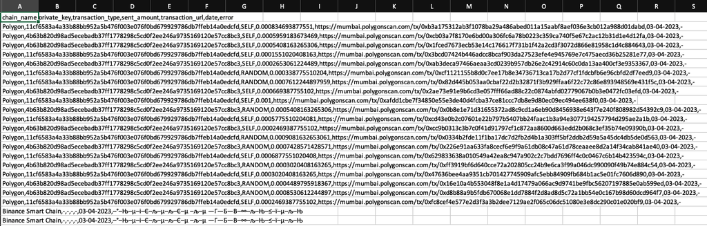

```python
from IPython.display import Image
Image("1.png", width=1120, height=240)
```

Откройте вкладку Данные, кнопку Внешние данные, Из текста:

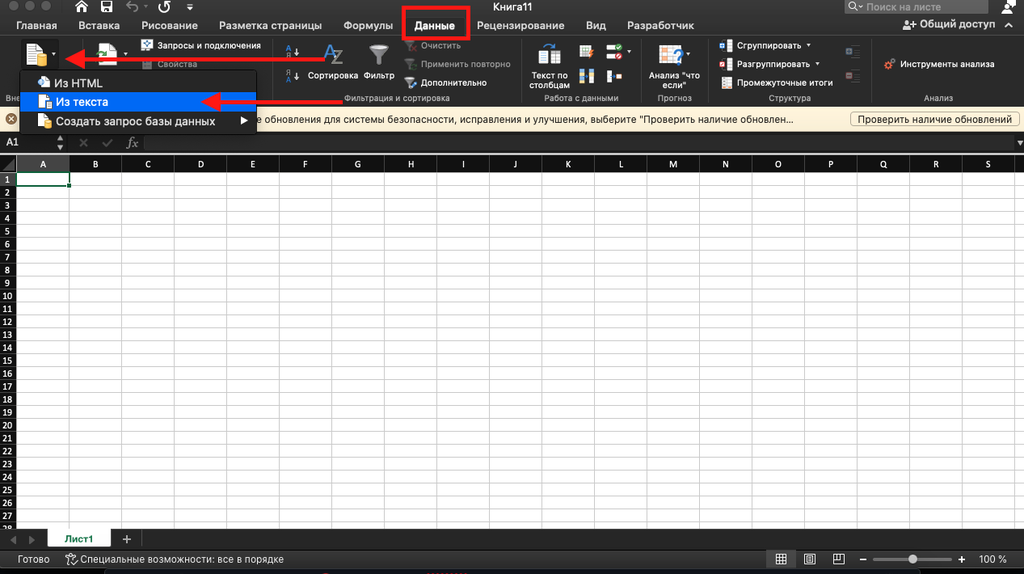

```python
from IPython.display import Image
Image("2.png", width=1120, height=240)
```

Выберете таблицу

[figure not shown]

```python
from IPython.display import Image
Image("3.png", width=800, height=240)
```

Выберете С разделителями, Формат файл, UTF-8, кнопка Далее

[figure not shown]

```python
from IPython.display import Image
Image("4.png", width=800, height=540)
```

Запятая, Готово

[figure not shown]

```python
from IPython.display import Image
Image("5.png", width=800, height=240)
```

На поля можно повесить Фильтр

[figure not shown]

```python
from IPython.display import Image
Image("6.png", width=800, height=240)
```

Фильтровать по уникальным значениям в каждом поле. На скрине отфильрованы строки по названию чейна, можно дальше фильтрануться по приватным ключам, посмотреть какие суммы были потрачены, за какие даты, посмотреть какие ошибки возникали и т.д.

[figure not shown]

```python
from IPython.display import Image
Image("7.png", width=800, height=240)
```